# Predict Points

## Purpose

To use ENMTools to figure out where we are most likely to find snails on an island (in this case, Santa Cruz).

## Set up

First, let’s get our libraries, files, and data set up.

```r
library(ENMTools)
library(raster)
library(plyr)
library(dplyr)
```

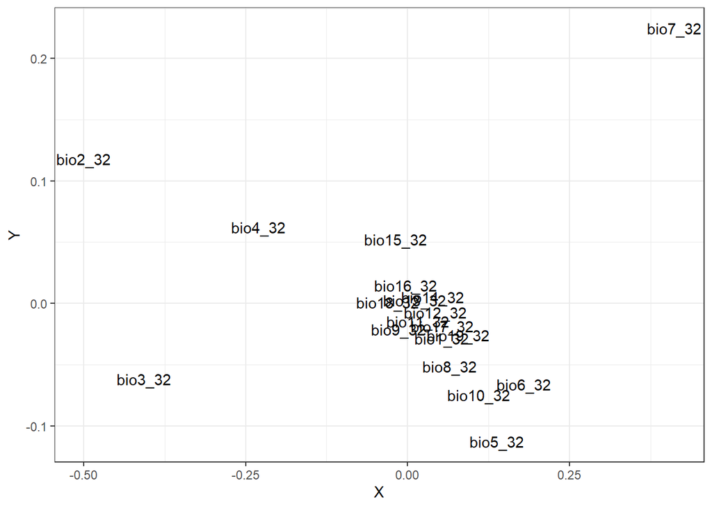

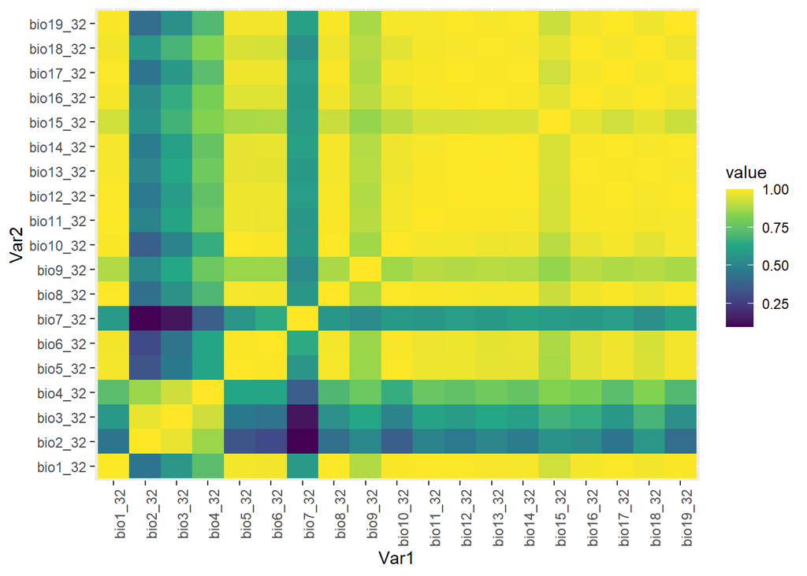

```r
# Depending on what species you want to include, choose a different file to read

# file <- read.csv("NaesiotusData_updatedNovember.csv") # 11/4/20
file <- read.csv("NaesiotusData_updatedNovember_Secondary.csv") # Uses secondary species names in updatedNovember

# Next, read in the CSV for species names

# This step is structured this way so we can easily add new/different species whenever we need to!
sp_list <- read.csv("species_names_Nov.csv") # For November_Secondary
species_list <- sp_list$ï..Species      # Weird i character because of Excel's extra characters

# After that, get your environment variables ready

# You can get 0.5 minute resolution (~1km^2) WorldClim data if you use a lon and lat for the tile you want
env <- raster::getData('worldclim', var='bio', res=0.5, lon = -90.44, lat = -0.69)

# Crop the environment to the extent we figured out in my previous .rmd
env <- crop(env, extent(-90.57163, -90.11387, -0.8867798, -0.3647284))

# Check the MDS to choose good variables and prevent colinearity
raster.cor.plot(env)
```

```r
# Choosing bio2, bio12, bio3, and bio7
env1 <- env[[c("bio2_32", "bio12_32", "bio3_32", "bio7_32")]]
```

## Create Suitability-Focused Dataframe of Points

Now that we have our basic setup, we can work on figuring out the most suitable spots for all of the snail species and combining them into a large dataframe to manipulate for our needs.

```r
# Initialize dataframe with my messy bloop blarp technique
# lon, lat, suitability, species
bloop <- c(-90, -0.3, 0.02, 'Ignore')
blarp <- c(-90, -0.3, 0.02, 'Ignore')

mega_snails <- rbind(bloop, blarp)
colnames(mega_snails) <- c("lon","lat","suitability","species")

# For each species in our list, find suitability info
for(sp in species_list) {
  species_name <- sp

  # Grab all row numbers that have this species
  selection <- which(file$Species == species_name)

  # Create new data frame with just that species' info and add to a massive dataframe
  species_data <- file[selection,]

  # Presence lat and lon
  lat <- species_data$Latitude
  lon <- species_data$Longitude
  latlong <- cbind.data.frame(lat, lon)

  # For now, background points are just points of other species
  anti_selection <- which(file$Species != species_name)

  # Create data frame with the background species' info
  background_data <- file[anti_selection,]

  # Background lat and lon
  lat <- background_data$Latitude
  lon <- background_data$Longitude
  latlongbg <- cbind.data.frame(lat, lon)

  # Make sure the background data does not have presence data points
  # Returns all rows from latlongbg WITHOUT a match in latlong
  latlongbg <- anti_join(latlongbg, latlong)

  # Declare the enmtools.species object using the species name and presence points
  snail <- enmtools.species(species.name = species_name,
                            presence.points = latlong)

  # ENMTools can create a range raster using presence points as a reference
  radius <- 5   # Radius for circular buffers to draw around points, in meters
  snail$range <- background.raster.buffer(snail$presence.points, radius, mask = env)

  # Add the background points to the enmtools.species object
  snail$background.points <- latlongbg

  # After creating the species object, use check.species to make sure it's set up properly
  snail <- check.species(snail)

  # Build the GLM
  snail.glm <- enmtools.glm(species = snail, env = env1, f = pres ~ bio2_32 + bio12_32 + bio3_32 + bio7_32)

  # Grab just the suitability part of the GLM
  suitable <- snail.glm$suitability

  # Turn the suitability information into a dataframe of points and suitability values
  suit_points <- rasterToPoints(suitable)
  df <- as.data.frame(suit_points)
  colnames(df) <-  c("lon", "lat", "suitability")
  df <- cbind(df, species=sp)     # Add the species as a column so we can match species to points

  # Grab all row numbers that have a high suitability (>=0.80)
  great_points <- which(df$suitability >= 0.80)

  # Create new data frame with just those rows
  points_df <- df[great_points,]

  # Bind these points to the mega dataframe
  mega_snails <- rbind(mega_snails, points_df)

}
```

[output not shown]

[output not shown]

[output not shown]

[output not shown]

[output not shown]

[output not shown]

[output not shown]

[output not shown]

[output not shown]

[output not shown]

[output not shown]

[output not shown]

[output not shown]

[output not shown]

[output not shown]

[output not shown]

[output not shown]

[output not shown]

[output not shown]

[output not shown]

[output not shown]

[output not shown]

[output not shown]

[output not shown]

[output not shown]

[output not shown]

[output not shown]

[output not shown]

[output not shown]

[output not shown]

[output not shown]

[output not shown]

[output not shown]

[output not shown]

[output not shown]

[output not shown]

[output not shown]

[output not shown]

[output not shown]

[output not shown]

[output not shown]

[output not shown]

[output not shown]

[output not shown]

[output not shown]

[output not shown]

[output not shown]

[output not shown]

[output not shown]

[output not shown]

[output not shown]

[output not shown]

[output not shown]

[output not shown]

[output not shown]

[output not shown]

[output not shown]

[output not shown]

[output not shown]

[output not shown]

[output not shown]

[output not shown]

[output not shown]

[output not shown]

[output not shown]

[output not shown]

[output not shown]

[output not shown]

[output not shown]

[output not shown]

[output not shown]

[output not shown]

[output not shown]

[output not shown]

[output not shown]

[output not shown]

[output not shown]

[output not shown]

[output not shown]

[output not shown]

[output not shown]

[output not shown]

[output not shown]

[output not shown]

[output not shown]

[output not shown]

[output not shown]

[output not shown]

[output not shown]

[output not shown]

[output not shown]

[output not shown]

[output not shown]

[output not shown]

[output not shown]

[output not shown]

[output not shown]

[output not shown]

[output not shown]

[output not shown]

[output not shown]

[output not shown]

[output not shown]

[output not shown]

[output not shown]

```r
mega_snails_1 <- mega_snails[-c(1,2),] # Delete the first two rows
```

## Use Suitability to Create a Grid Over the Island

Originally, I was trying to use a range of latitudes and longitudes to figure out a specific location where the most snail species can be found, but combining the two into a good square was proving to be difficult. Luke suggested that I should create a grid in which each square contained a certain amount of suitability points. Ultimately, the square with the most points would be the best place to go to find snails.

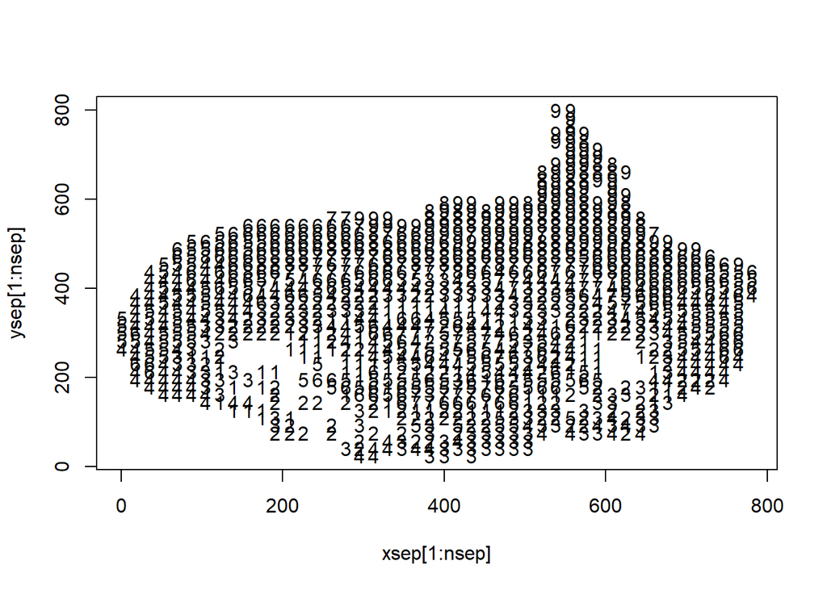

```r
# First, determine max/min lat/lon
# (from Google Earth)
maxLat <- -0.3875     # From mega_snails
# maxLat <- -0.413861   # Top
minLat <- -0.773690   # Bottom

maxLon <- -90.169965  # Right
# minLon <- -90.548057  # Left
minLon <- -90.55417   # From mega_snails

# Next, create a function to give you the square that the coordinate goes into

grid <- function(lat, lon) {
  latsq <- (lat - minLat)/(maxLat-minLat) * 800  # 800 squares
  latsq <- ceiling(latsq)                        # Take the ceiling of the result

  lonsq <- (lon - minLon)/(maxLon-minLon) * 800
  lonsq <- ceiling(lonsq)

  return(c(lonsq,latsq))
}

# Make a new dataframe
# Species, lonsq, latsq
bloop <- c('Ignore', 1, 2)
blarp <- c('Ignore', 1, 2)
sq_species <- rbind(bloop, blarp)
colnames(sq_species) <- c("species", "lonsq", "latsq")

# Now go through mega_snails_1 to find where each lat/lon pair goes
for(r in 1:nrow(mega_snails_1)) {
  # Get lat and lon
  lat <- as.numeric(mega_snails_1[r,2])
  lon <- as.numeric(mega_snails_1[r,1])

  # Find the grid coordinate
  sq_pair <- grid(lat,lon)

  # Add the species name
  species <- mega_snails_1[r,4]

  # rbind the new info to the dataframe
  add <- c(species, sq_pair)
  sq_species <- rbind(sq_species, add)
}

sq_species_1 <- sq_species[-c(1,2),] # Delete the first two rows

df <- as.data.frame(sq_species_1) # Convert to a dataframe for easier plotting

# I wanted to visualize how many points overlap, so I used this library:
library(plotrix)
count.overplot(as.numeric(df$lonsq), as.numeric(df$latsq), tol = 0)
```

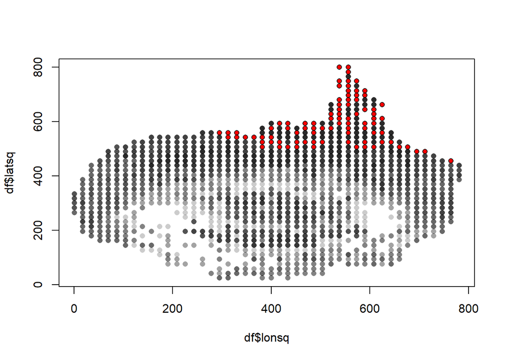

```r
# Create a dataframe of just the coordinates for easier plyr use
coord <- data.frame(df$lonsq, df$latsq)

# Figure out how many rows are the same (how many coordinates overlap)
coord_same <- ddply(coord, .(coord$df.lonsq,coord$df.latsq), nrow)

# Get rows that have >= 9 of the same coordinates
lotsosnails <- which(coord_same$V1 >= 9)
snail_df <- coord_same[lotsosnails,]

# Finally, plot the grid squares with the greatest number of species in red
# Fewest number of species are closer to white on the grayscale
plot(df$lonsq, df$latsq, col = rgb(red = 0, green = 0, blue = 0, alpha = 0.2),
     pch = 16)
points(snail_df$`coord$df.lonsq`, snail_df$`coord$df.latsq`, col = 'red', pch = 20)
```